# Data Analysis and Visualization Project

Jaskirandeep Kaur

12/9/2019

This is my final project for HS631. It goes through data cleaning, analysis and visualization of the births data set.

Dataset variables (1000 births):

dad_age Age of father of baby (years)

mom_age Age of mother of baby (years)

maturity Classify mother as of advanced maternal age or not (younger / advanced)

len_preg Length of pregnancy (weeks)

is_premie Classify baby as either premature or full-term (premie / fullterm)

num_visits Number of visits to hospital during pregnancy

marital Marital status of mother at time of birth (unmarried / married)

mom_wt_gain Mother’s weight gain during pregnancy (pounds)

bwt Birth weight of baby (pounds)

low_bwt Classify baby as either low birthweight or not (low / notlow)

sex Sex of baby (female / male)

smoke Smoking status of mother (nonsmoker / smoker)

mom_white Classify mother as either white or not (nonwhite / white)

mom_age_level Age level of mother of baby (teens, early20s, late20s, early30s, 35+)

Loading the data into a dataframe

```r
.libPaths('C:/Users/kirak/R')
setwd('C:/Users/kirak/HS631')
load(file = 'C:/Users/kirak/HS631/births.Rdat')
```

Loading Libraries

```r
library(ggplot2)
library(plyr)
library(corrplot)
library("pwr")
library(rgl)
library(pscl)
library(car)
library (stats)
```

Cleaning the data of impossible values and turning those into NA’s

```r
summary(births)
```

```
##     dad_age         mom_age      maturity      len_preg         is_premie
##  Min.   : 14.0   Min.   :13   advnced:133   Min.   : 20.00   fullterm:846
##  1st Qu.: 26.0   1st Qu.:22   younger:867   1st Qu.: 37.00   premie  :152
##  Median : 32.0   Median :27                 Median : 39.00   unknown :  2
##  Mean   :195.9   Mean   :27                 Mean   : 40.26
##  3rd Qu.: 39.0   3rd Qu.:32                 3rd Qu.: 40.00
##  Max.   :999.0   Max.   :50                 Max.   :999.00
##    num_visits          marital     mom_wt_gain          bwt
##  Min.   :  0.00   married  :613   Min.   :  0.00   Min.   : 1.000
##  1st Qu.: 10.00   unknown  :  1   1st Qu.: 21.00   1st Qu.: 6.380
##  Median : 12.00   unmarried:386   Median : 30.00   Median : 7.310
##  Mean   : 20.99                   Mean   : 56.48   Mean   : 7.101
##  3rd Qu.: 15.00                   3rd Qu.: 40.00   3rd Qu.: 8.060
##  Max.   :999.00                   Max.   :999.00   Max.   :11.750
##    low_bwt        sex            smoke        mom_white    mom_age_level
##  low   :111   female:503   nonsmoker:873   nonwhite:284   35+     :133
##  notlow:889   male  :497   smoker   :126   unknown :  2   early20s:281
##                            unknown  :  1   white   :714   early30s:219
##                                                           late20s :257
##                                                           teens   :110
##
```

```r
#cleaning the data
births$dad_age[births$dad_age == 999] <- NA
births$len_preg[births$len_preg == 999] <- NA
births$num_visits[births$num_visits == 999] <-NA
births$mom_wt_gain[births$mom_wt_gain == 999] <- NA
```

Rearranging the ranks of factored variables in their right order and creating suitable labels.

```r
births$maturity<-factor(births$maturity, levels=c("younger","advnced"),labels=c("Younger","Advanced"))
births$is_premie<-factor(births$is_premie, levels=c("premie","fullterm"),labels=c("Premie","Full-term"))
births$marital<-factor(births$marital, levels=c("unmarried","married"),labels=c("Unmarried","Married"))
births$low_bwt<-factor(births$low_bwt, levels=c("notlow","low"), labels=c("Not Low", "Low"))
births$sex<-factor(births$sex, levels=c("female","male"), labels=c("Female","Male"))
births$smoke<-factor(births$smoke, levels=c("nonsmoker","smoker"), labels=c("Non-Smoker","Smoker"))
births$mom_age_level<-factor(births$mom_age_level, levels=c("teens","early20s","late20s","early30s","35+"),labels=c("Teens","Early 20's","Late 20's","Early 30's","35+"))
births$mom_white<-factor(births$mom_white, levels=c("nonwhite","white"),labels=c("Non-White", "White"))
summary(births)
```

```
##     dad_age         mom_age       maturity      len_preg         is_premie
##  Min.   :14.00   Min.   :13   Younger :867   Min.   :20.00   Premie   :152
##  1st Qu.:25.00   1st Qu.:22   Advanced:133   1st Qu.:37.00   Full-term:846
##  Median :30.00   Median :27                  Median :39.00   NA's     :  2
##  Mean   :30.26   Mean   :27                  Mean   :38.33
##  3rd Qu.:35.00   3rd Qu.:32                  3rd Qu.:40.00
##  Max.   :55.00   Max.   :50                  Max.   :45.00
##  NA's   :171                                 NA's   :2
##    num_visits        marital     mom_wt_gain         bwt            low_bwt
##  Min.   : 0.0   Unmarried:386   Min.   : 0.00   Min.   : 1.000   Not Low:889
##  1st Qu.:10.0   Married  :613   1st Qu.:20.00   1st Qu.: 6.380   Low    :111
##  Median :12.0   NA's     :  1   Median :30.00   Median : 7.310
##  Mean   :12.1                   Mean   :30.33   Mean   : 7.101
##  3rd Qu.:15.0                   3rd Qu.:38.00   3rd Qu.: 8.060
##  Max.   :30.0                   Max.   :85.00   Max.   :11.750
##  NA's   :9                      NA's   :27
##      sex             smoke         mom_white      mom_age_level
##  Female:503   Non-Smoker:873   Non-White:284   Teens     :110
##  Male  :497   Smoker    :126   White    :714   Early 20's:281
##               NA's      :  1   NA's     :  2   Late 20's :257
##                                                Early 30's:219
##                                                35+       :133
##
##
```

Plotting Distributions of Univariate Variables.

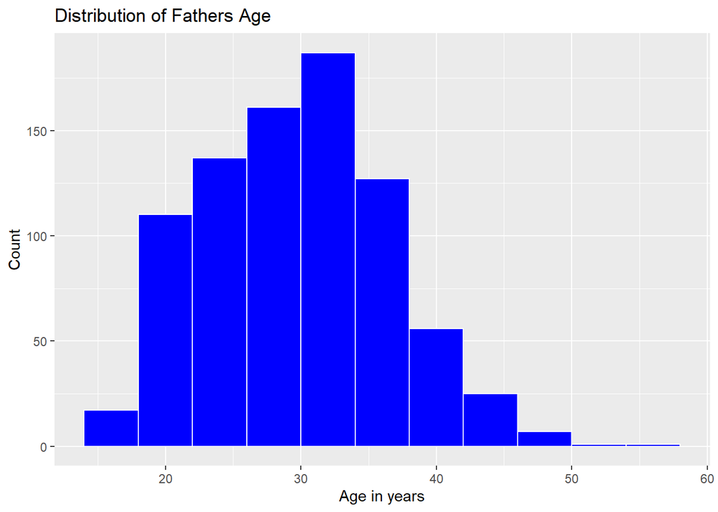

```r
ggplot(births, aes(x=dad_age)) + geom_histogram(binwidth = 4, color="white",fill="blue") + ggtitle("Distribution of Fathers Age") + xlab("Age in years") + ylab("Count")
```

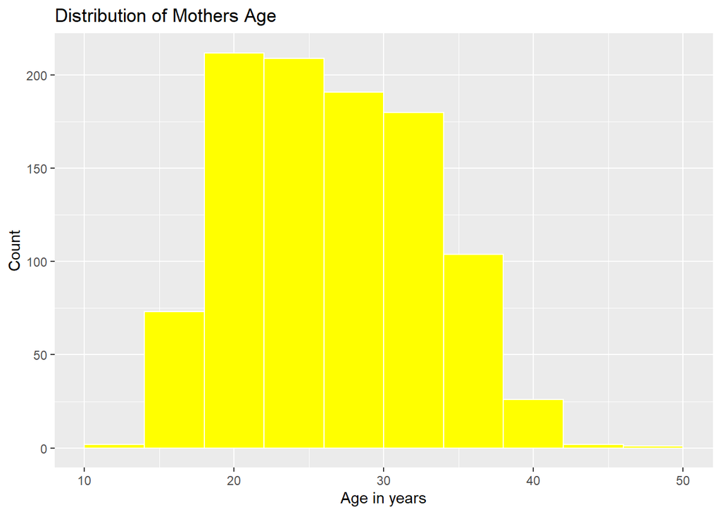

```r
ggplot(births, aes(x=mom_age)) + geom_histogram(binwidth = 4, color="white",fill="yellow") + ggtitle("Distribution of Mothers Age") + xlab("Age in years") + ylab("Count")
```

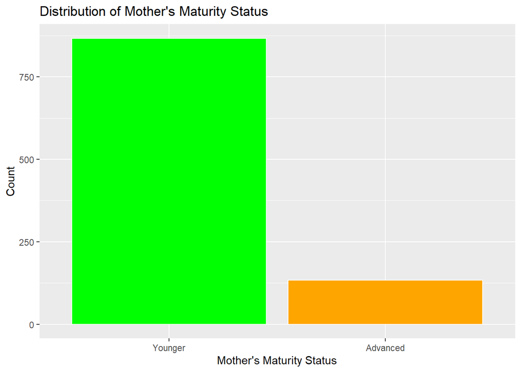

```r
ggplot(births, aes(x=maturity)) + geom_bar(color="white",fill=c("green","orange")) + ggtitle("Distribution of Mother's Maturity Status") + xlab("Mother's Maturity Status") + ylab("Count")
```

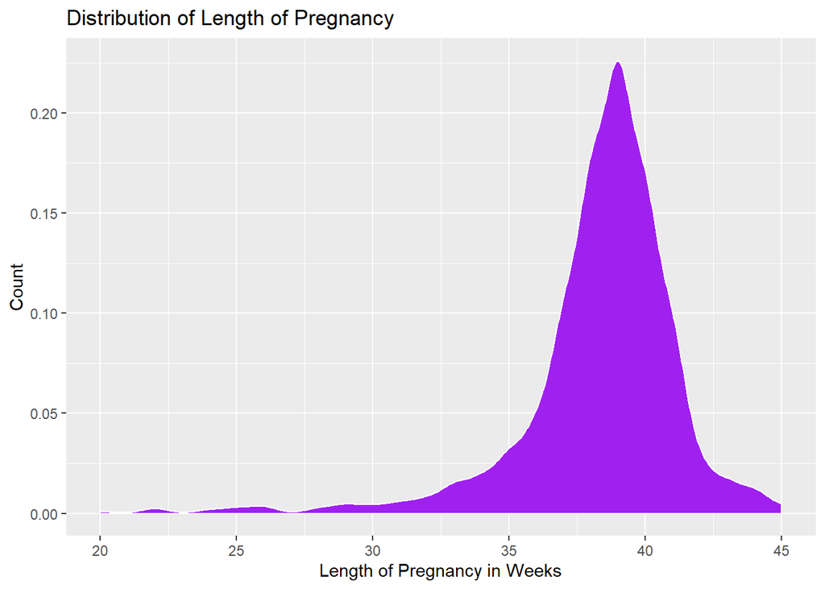

```r
ggplot(births, aes(x=len_preg)) + geom_density(color="white",fill="purple") + ggtitle("Distribution of Length of Pregnancy") + xlab("Length of Pregnancy in Weeks") + ylab("Count")
```

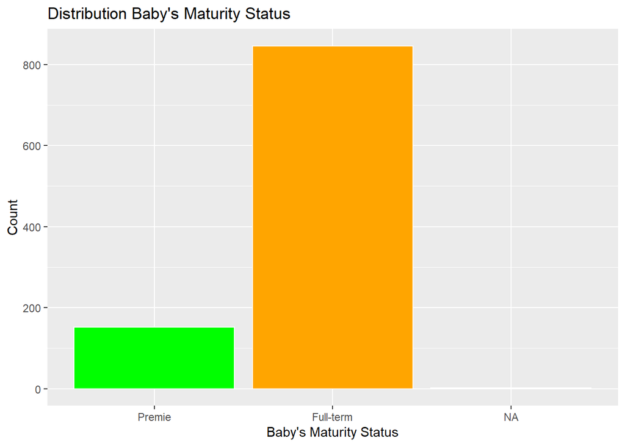

```r
ggplot(births, aes(x=is_premie)) + geom_bar(color="white",fill=c("green","orange","red")) + ggtitle("Distribution Baby's Maturity Status") + xlab("Baby's Maturity Status") + ylab("Count")
```

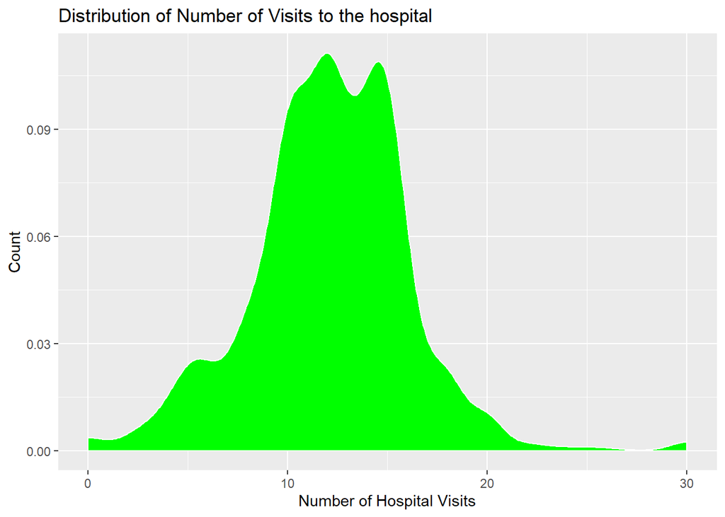

```r
ggplot(births, aes(x=num_visits)) + geom_density(color="white",fill="green") + ggtitle("Distribution of Number of Visits to the hospital") + xlab("Number of Hospital Visits") + ylab("Count")
```

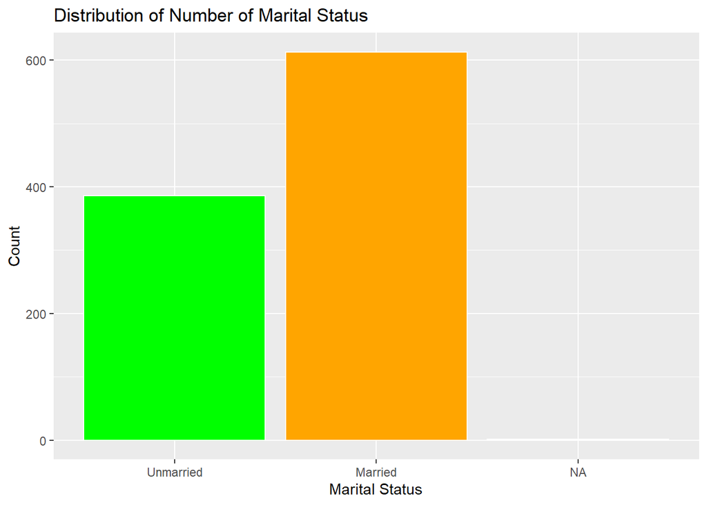

```r
ggplot(births, aes(x=marital)) + geom_bar(color="white",fill=c("green","orange","red")) + ggtitle("Distribution of Number of Marital Status") + xlab("Marital Status") + ylab("Count")
```

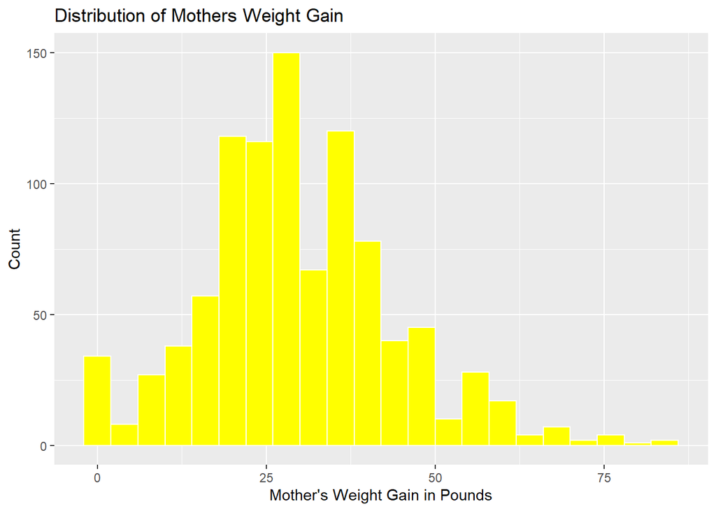

```r
ggplot(births, aes(x=mom_wt_gain)) + geom_histogram(binwidth = 4, color="white",fill="yellow") + ggtitle("Distribution of Mothers Weight Gain") + xlab("Mother's Weight Gain in Pounds") + ylab("Count")
```

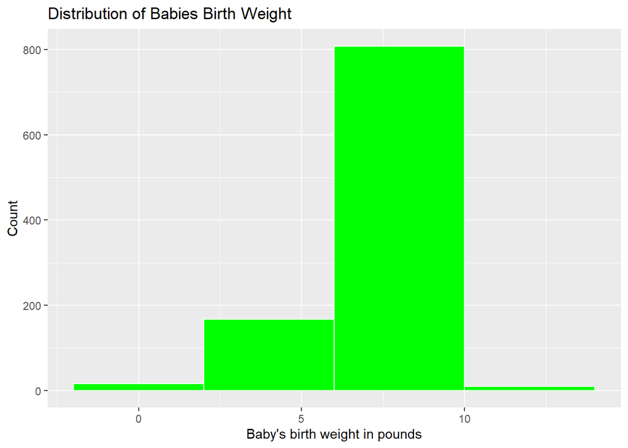

```r
ggplot(births, aes(x=bwt)) + geom_histogram(binwidth = 4, color="white",fill="green") + ggtitle("Distribution of Babies Birth Weight") + xlab("Baby's birth weight in pounds") + ylab("Count")
```

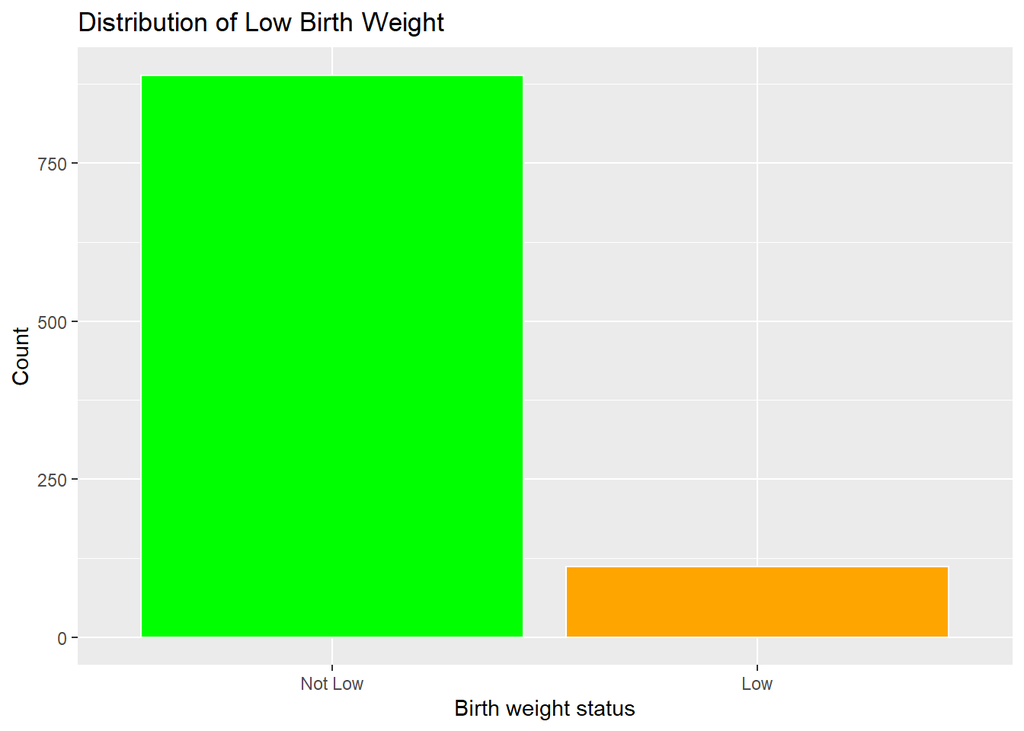

```r
ggplot(births, aes(x=low_bwt)) + geom_bar(color="white",fill=c("green","orange")) + ggtitle("Distribution of Low Birth Weight") + xlab("Birth weight status") + ylab("Count")
```

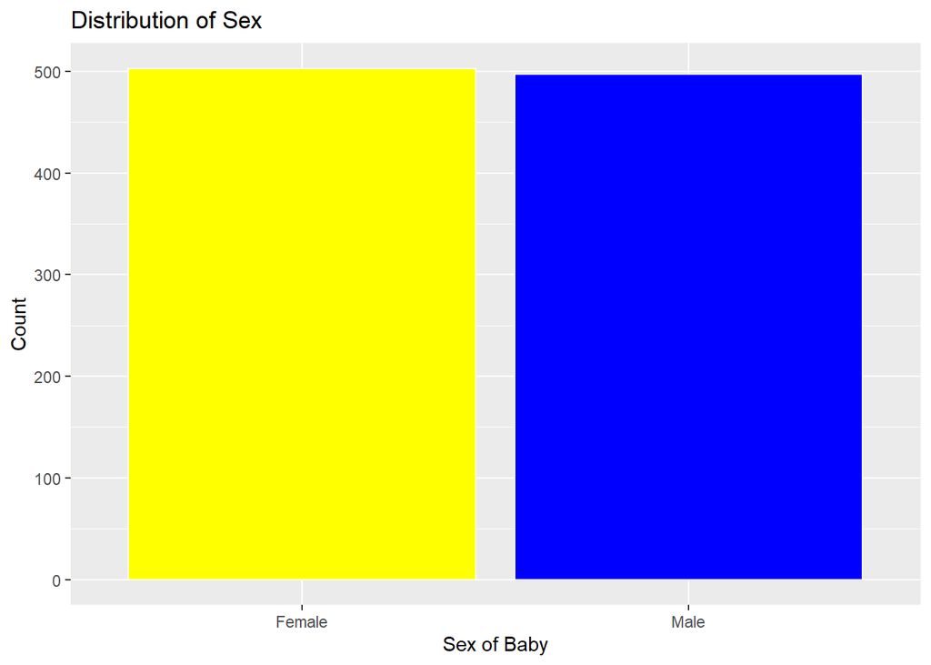

```r
ggplot(births, aes(x=sex)) + geom_bar(color="white",fill=c("yellow","blue")) + ggtitle("Distribution of Sex") + xlab("Sex of Baby") + ylab("Count")
```

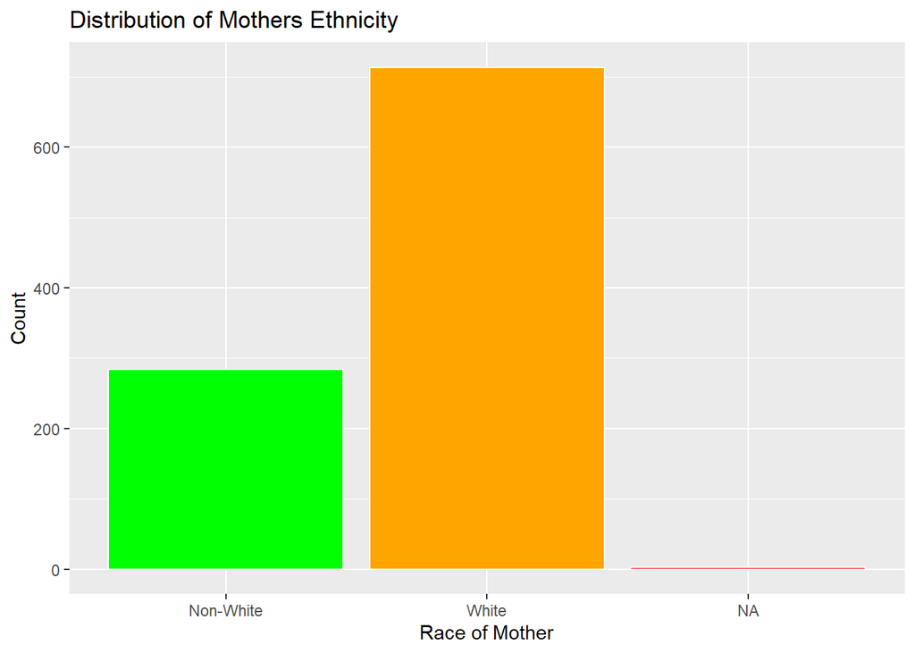

```r
ggplot(births, aes(x=mom_white)) + geom_bar(color="white",fill=c("green","orange","red")) + ggtitle("Distribution of Mothers Ethnicity") + xlab("Race of Mother") + ylab("Count")
```

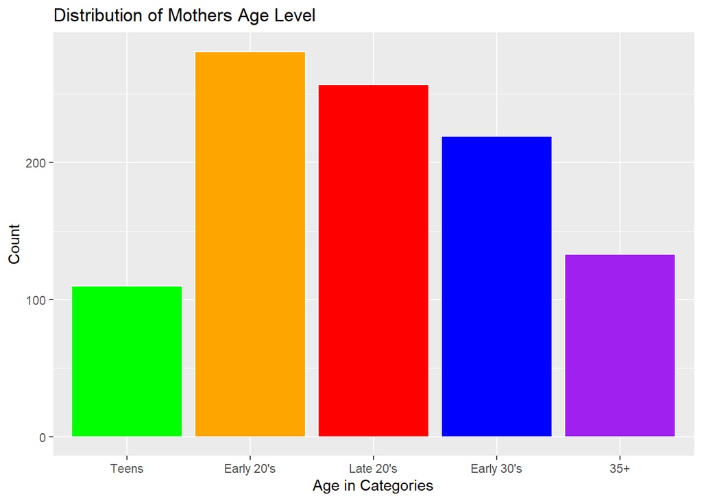

```r
ggplot(births, aes(x=mom_age_level)) + geom_bar(color="white",fill=c("green","orange","red","blue","purple")) + ggtitle("Distribution of Mothers Age Level") + xlab("Age in Categories") + ylab("Count")
```

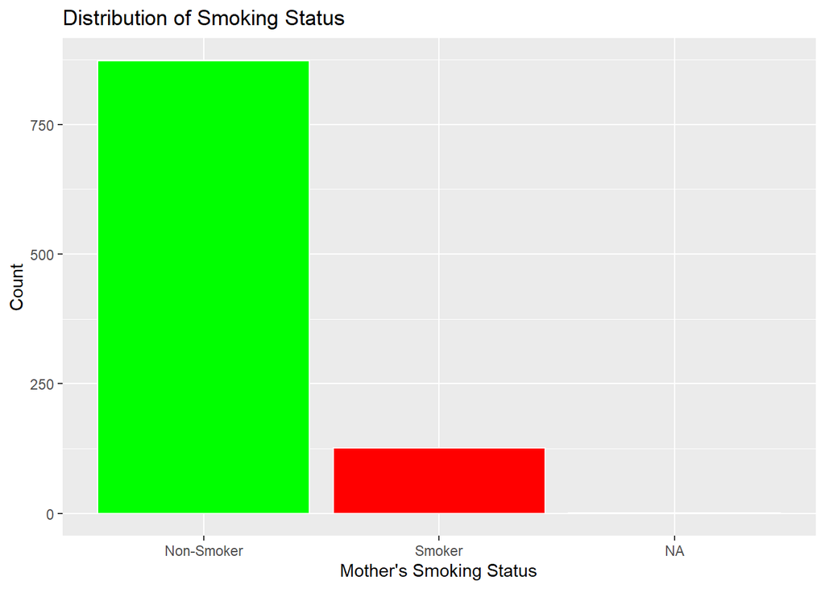

```r
ggplot(births, aes(x=smoke)) + geom_bar(color="white",fill=c("green","red","orange")) + ggtitle("Distribution of Smoking Status") + xlab("Mother's Smoking Status") + ylab("Count")
```

Plotting Bivariate Distributions of Specific Variables

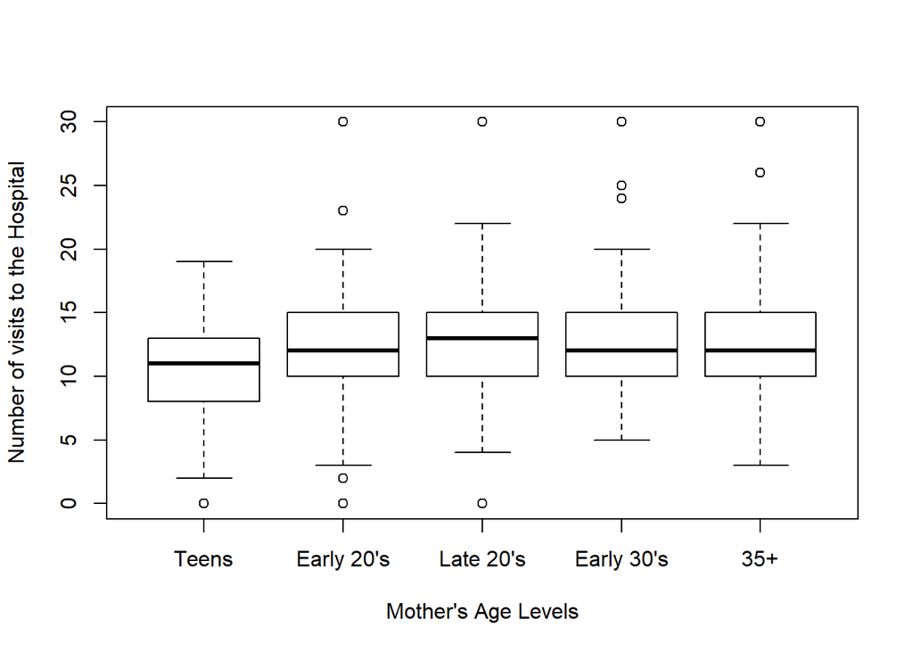

```r
plot(births$mom_age_level,births$num_visits,xlab="Mother's Age Levels", ylab="Number of visits to the Hospital")
```

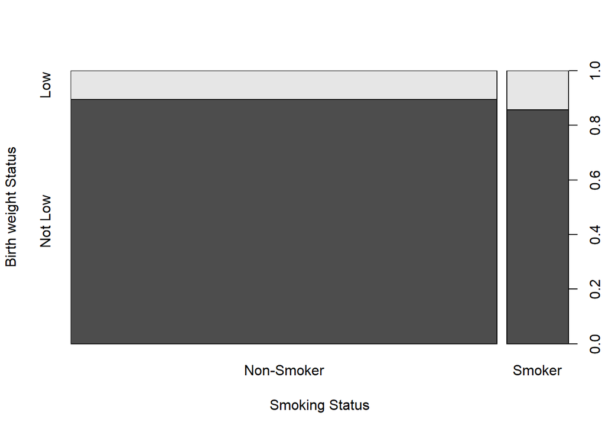

```r
plot(births$smoke,births$low_bwt, xlab="Smoking Status", ylab="Birth weight Status")
```

Interpretation: The first plot shows that teens tend to have less number of hospital vistis will pregnant compared to that of the other 4 age levels. The second plot shows that there is slightly more low birth weight status babies of mother’s that do smoke compared to that of non-smoking mothers.

Plotting Trivariate Distributions of Specific Variables.

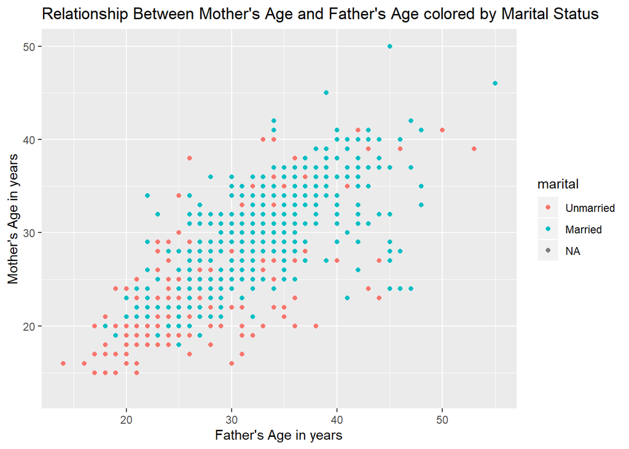

```r
ggplot(births, aes(x=dad_age, y=mom_age, color=marital)) + geom_point() +  ggtitle("Relationship Between Mother's Age and Father's Age colored by Marital Status") + xlab("Father's Age in years") + ylab("Mother's Age in years")
```

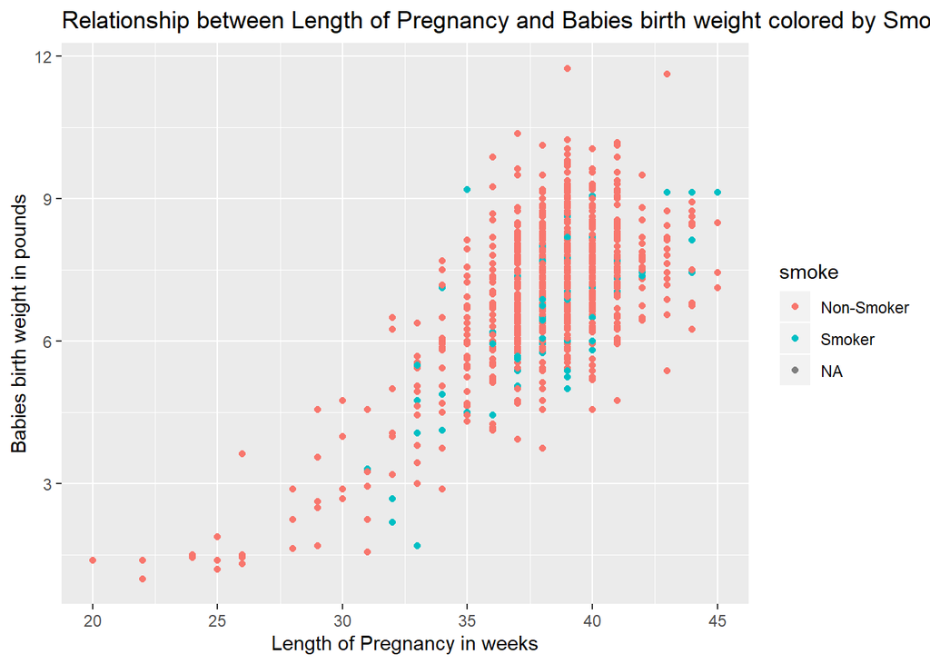

```r
ggplot(births, aes(x=len_preg, y=bwt, color=smoke)) + geom_point() + ggtitle("Relationship between Length of Pregnancy and Babies birth weight colored by Smoking status") + xlab("Length of Pregnancy in weeks") + ylab("Babies birth weight in pounds")
```

Interpretation: The first plot shows a steady positive increase of both mother’s and father’s age. With most unmarried marital status below 25 years of age. The second plot shows that as lenght of pregnancy increases so those that of the birthweight of the babies, which is expected. Also you can see that babies of mothers that do smoke tend to lie slightly below their peers.

Power Analysis for Chisquared,Correlation and Two sample unpaired T-test.

```r
#chisquared power
pwr.chisq.test(w =.3, df=1,N =1000 , sig.level =.05)
```

```
##
##      Chi squared power calculation
##
##               w = 0.3
##               N = 1000
##              df = 1
##       sig.level = 0.05
##           power = 1
##
## NOTE: N is the number of observations
```

```r
#calculate df
```

Interpretation: For an effect size of .3, a sample population of 1000, significance level at .05(The alpha cut off), and 1 degree of freedom. It shows a power of 1. Within these parameters the power of this study is ideal.

```r
#correlation power
pwr.r.test(n =1000 , r = .1, sig.level = .05)
```

```
##
##      approximate correlation power calculation (arctangh transformation)
##
##               n = 1000
##               r = 0.1
##       sig.level = 0.05
##           power = 0.8867836
##     alternative = two.sided
```

```r
pwr.r.test(r = .1, sig.level = .05, power = .95)
```

```
##
##      approximate correlation power calculation (arctangh transformation)
##
##               n = 1292.88
##               r = 0.1
##       sig.level = 0.05
##           power = 0.95
##     alternative = two.sided
```

```r
#ttest power
count(births$low_bwt)
```

```
##         x freq
## 1 Not Low  889
## 2     Low  111
```

```r
pwr.t2n.test(n1=111, n2=889, d = .2, sig.level = .05 )
```

```
##
##      t test power calculation
##
##              n1 = 111
##              n2 = 889
##               d = 0.2
##       sig.level = 0.05
##           power = 0.5099606
##     alternative = two.sided
```

```r
pwr.t2n.test(n1=889, d = .2, sig.level = .05, power=.95 )
```

```
##
##      t test power calculation
##
##              n1 = 889
##              n2 = 513.0591
##               d = 0.2
##       sig.level = 0.05
##           power = 0.95
##     alternative = two.sided
```

```r
pwr.t2n.test(n1=111, n2=889, sig.level = .05, power=.95 )
```

```
##
##      t test power calculation
##
##              n1 = 111
##              n2 = 889
##               d = 0.3632318
##       sig.level = 0.05
##           power = 0.95
##     alternative = two.sided
```

Interpretation: The first power test for the two sample unpaired t test shows that within these parameters the power analysis is at .51 which is decent but could be better. The second power analysis shows that for an effect size of .2, significance level of .05 and a power of .95. 513 is needed for the second sample size population to be. The third power analysis shows that for these parameters we will attain an effect size of .36

Two Sample T-Test

```r
t.test(births$len_preg~births$low_bwt)
```

```
##
##  Welch Two Sample t-test
##
## data:  births$len_preg by births$low_bwt
## t = 12.188, df = 113.43, p-value < 2.2e-16
## alternative hypothesis: true difference in means is not equal to 0
## 95 percent confidence interval:
##  4.618782 6.411808
## sample estimates:
## mean in group Not Low     mean in group Low
##              38.94257              33.42727
```

```r
t.test(births$mom_wt_gain~births$low_bwt)
```

```
##
##  Welch Two Sample t-test
##
## data:  births$mom_wt_gain by births$low_bwt
## t = 3.1887, df = 127.93, p-value = 0.001797
## alternative hypothesis: true difference in means is not equal to 0
## 95 percent confidence interval:
##  1.805305 7.709434
## sample estimates:
## mean in group Not Low     mean in group Low
##              30.83429              26.07692
```

Interpretation: First two sample unpaired t-test: The sample estimates show the average length of pregnancy in weeks for babies with low birth weight and not low birth weight within this sample population. The confidence interval shows that there is a 95 percent chance that the real population sample mean of length of pregnancy between low birth weight babies and not low birth weight babies will be between -6.41 to -4.62. The p value is <2.2e-16 which is well below the alpha cut off .05. With this information we reject the null hypothesis that there is no difference between the means of these two samples. Since there is clearly a difference between the two means and it is not equal to 0. Second two sample unpaired t-test: The sample estimates show the average weight gain for mothers in pounds for babies with low birth weight and not low birth weight within this sample population. The confidence interval shows that there is a 95 percent chance that the real population sample mean of mother’s weight gain between low birth weight babies and not low birth weight babies will be between -7.71 to -1.81. The p value is .0017 which is below the alpha cut off .05. With this information we reject the null hypothesis that there is no difference between the means of low birth weight and not low birth weight babies. The difference is not equal to 0.

Anova Test

```r
fit_an = lm(bwt ~ mom_age_level, data=births)
summary(fit_an)
```

```
##
## Call:
## lm(formula = bwt ~ mom_age_level, data = births)
##
## Residuals:
##     Min      1Q  Median      3Q     Max
## -6.1755 -0.6895  0.1824  0.9545  4.5524
##
## Coefficients:
##                         Estimate Std. Error t value Pr(>|t|)
## (Intercept)               6.7853     0.1437  47.224   <2e-16 ***
## mom_age_levelEarly 20's   0.2843     0.1695   1.677   0.0938 .
## mom_age_levelLate 20's    0.3902     0.1717   2.273   0.0233 *
## mom_age_levelEarly 30's   0.4124     0.1761   2.341   0.0194 *
## mom_age_level35+          0.3403     0.1942   1.752   0.0801 .
## ---
## Signif. codes:  0 '***' 0.001 '**' 0.01 '*' 0.05 '.' 0.1 ' ' 1
##
## Residual standard error: 1.507 on 995 degrees of freedom
## Multiple R-squared:  0.006505,   Adjusted R-squared:  0.002511
## F-statistic: 1.629 on 4 and 995 DF,  p-value: 0.1648
```

```r
a_mcv <- aov(fit_an)
a_mcv
```

```
## Call:
##    aov(formula = fit_an)
##
## Terms:
##                 mom_age_level Residuals
## Sum of Squares        14.7942 2259.5884
## Deg. of Freedom             4       995
##
## Residual standard error: 1.506965
## Estimated effects may be unbalanced
```

Tukey Test

```r
a_mcv_tukey<- TukeyHSD(a_mcv)
a_mcv_tukey
```

```
##   Tukey multiple comparisons of means
##     95% family-wise confidence level
##
## Fit: aov(formula = fit_an)
##
## $mom_age_level
##                              diff         lwr       upr     p adj
## Early 20's-Teens       0.28426464 -0.17891297 0.7474423 0.4485909
## Late 20's-Teens        0.39021365 -0.07900883 0.8594361 0.1546547
## Early 30's-Teens       0.41235284 -0.06891654 0.8936222 0.1327897
## 35+-Teens              0.34029118 -0.19045840 0.8710408 0.4024842
## Late 20's-Early 20's   0.10594901 -0.24950228 0.4614003 0.9261967
## Early 30's-Early 20's  0.12808820 -0.24312077 0.4992972 0.8800208
## 35+-Early 20's         0.05602654 -0.37741434 0.4894674 0.9966653
## Early 30's-Late 20's   0.02213919 -0.35658543 0.4008638 0.9998539
## 35+-Late 20's         -0.04992247 -0.48981705 0.3899721 0.9979920
## 35+-Early 30's        -0.07206166 -0.52478422 0.3806609 0.9925572
```

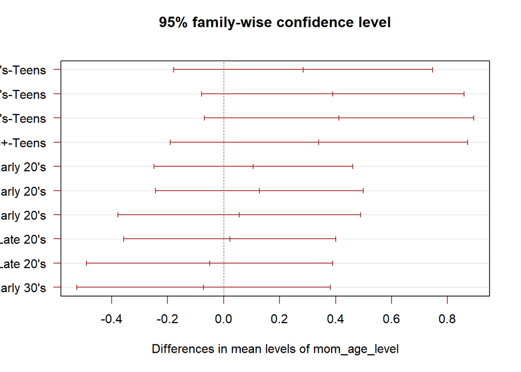

```r
plot(a_mcv_tukey , las=1 , col="brown")
```

Interpretation: The groups with the largest difference in means are early20s-teens, late20s-teens, early30s-teens, 35+-teens.

Chi-squared Test

```r
chisq.test(births$low_bwt, births$is_premie)
```

```
##
##  Pearson's Chi-squared test with Yates' continuity correction
##
## data:  births$low_bwt and births$is_premie
## X-squared = 311.57, df = 1, p-value < 2.2e-16
```

Interpretation: We reject the Null hypothesis of the variables being independent. According to a pvalue of <2.2e-16 The variables are dependent.

Wilcoxon-Mann Whitney test

```r
wilcox.test(bwt ~ smoke, data=births)
```

```
##
##  Wilcoxon rank sum test with continuity correction
##
## data:  bwt by smoke
## W = 63382, p-value = 0.005622
## alternative hypothesis: true location shift is not equal to 0
```

Interpretation: The p-value is 0.005622, which is less than the significance level alpha cut off of 0.05. We can conclude that median birthweight for non smoking mothers and smoking mothers is different.

Pearson Correlation of data set

```r
c1<-cor(births[,c(1,2,4,6,8,9)], use="pairwise.complete.obs")
c1
```

```
##                 dad_age     mom_age    len_preg num_visits mom_wt_gain
## dad_age      1.00000000  0.78050678 -0.01607193 0.08138687 -0.04310050
## mom_age      0.78050678  1.00000000 -0.03208743 0.16062202 -0.06063533
## len_preg    -0.01607193 -0.03208743  1.00000000 0.17613607  0.09140028
## num_visits   0.08138687  0.16062202  0.17613607 1.00000000  0.05986466
## mom_wt_gain -0.04310050 -0.06063533  0.09140028 0.05986466  1.00000000
## bwt          0.07023403  0.05506589  0.67010134 0.13488301  0.15417155
##                    bwt
## dad_age     0.07023403
## mom_age     0.05506589
## len_preg    0.67010134
## num_visits  0.13488301
## mom_wt_gain 0.15417155
## bwt         1.00000000
```

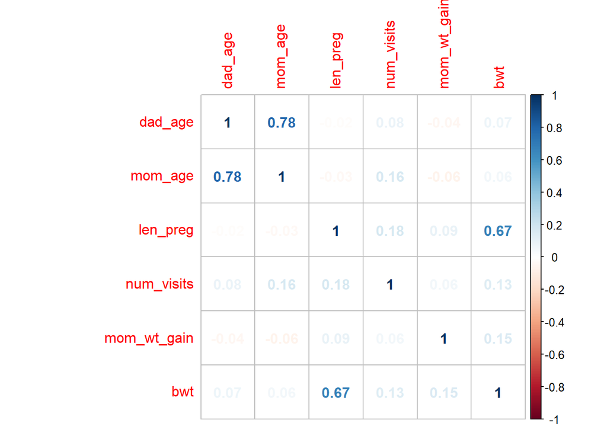

```r
corrplot(c1, method="number")
```

Interpretation: According to this plot we can see that Father’s age and Mother’s age is highly correlated at .78. We can also see length of pregnancy and babies birth weight at .67

Subsetting Births into Births2 and changing Factored Variables into Numeric.

```r
births2<-births
births2$maturity <-as.numeric(births2$maturity)
births2$is_premie <- as.numeric(births2$is_premie)
births2$marital <- as.numeric(births2$marital)
births2$low_bwt <- as.numeric(births2$low_bwt)
births2$sex <- as.numeric(births2$sex)
births2$smoke <- as.numeric(births2$smoke)
births2$mom_white <- as.numeric(births2$mom_white)
births2$mom_age_level <- as.numeric(births2$mom_age_level)
```

Spearman Correlation of Births2 data set

```r
c2<-cor(births2, use="pairwise.complete.obs", method="spearman")
c2
```

```
##                    dad_age      mom_age     maturity     len_preg    is_premie
## dad_age        1.000000000  0.794262548  0.481485708 -0.031710050  0.004102886
## mom_age        0.794262548  1.000000000  0.588819814 -0.042773785  0.012752560
## maturity       0.481485708  0.588819814  1.000000000 -0.034195286 -0.023836636
## len_preg      -0.031710050 -0.042773785 -0.034195286  1.000000000  0.630651495
## is_premie      0.004102886  0.012752560 -0.023836636  0.630651495  1.000000000
## num_visits     0.059006014  0.143410609  0.048242501  0.137871772  0.143264817
## marital        0.358941381  0.453100372  0.157858725  0.020186892  0.087095443
## mom_wt_gain   -0.045526551 -0.050281512 -0.047378454  0.065762657  0.145907527
## bwt            0.086371777  0.076181800  0.020012654  0.452590772  0.445992768
## low_bwt       -0.005760923 -0.006005699  0.030345546 -0.416282434 -0.563192923
## sex            0.059692174 -0.002254230 -0.006484698  0.025143334 -0.030435326
## smoke         -0.103885980 -0.108385376 -0.050294575 -0.008966556  0.001598465
## mom_white      0.130724383  0.179408733  0.056131765  0.053478896  0.078280577
## mom_age_level  0.770025057  0.974049888  0.604506834 -0.041156960  0.010809773
##                num_visits      marital mom_wt_gain         bwt      low_bwt
## dad_age        0.05900601  0.358941381 -0.04552655  0.08637178 -0.005760923
## mom_age        0.14341061  0.453100372 -0.05028151  0.07618180 -0.006005699
## maturity       0.04824250  0.157858725 -0.04737845  0.02001265  0.030345546
## len_preg       0.13787177  0.020186892  0.06576266  0.45259077 -0.416282434
## is_premie      0.14326482  0.087095443  0.14590753  0.44599277 -0.563192923
## num_visits     1.00000000  0.218592128  0.07083079  0.10020952 -0.122843661
## marital        0.21859213  1.000000000  0.04019315  0.15149952 -0.121480719
## mom_wt_gain    0.07083079  0.040193147  1.00000000  0.18096286 -0.120832286
## bwt            0.10020952  0.151499522  0.18096286  1.00000000 -0.544169401
## low_bwt       -0.12284366 -0.121480719 -0.12083229 -0.54416940  1.000000000
## sex           -0.04755096  0.004251541  0.05119186  0.16461252 -0.020163852
## smoke         -0.06872315 -0.107220940  0.04326961 -0.08765839  0.039743707
## mom_white      0.07975005  0.330148687  0.08262090  0.17073331 -0.080610599
## mom_age_level  0.14038995  0.443794113 -0.04123870  0.07334022 -0.001966450
##                        sex        smoke   mom_white mom_age_level
## dad_age        0.059692174 -0.103885980  0.13072438   0.770025057
## mom_age       -0.002254230 -0.108385376  0.17940873   0.974049888
## maturity      -0.006484698 -0.050294575  0.05613177   0.604506834
## len_preg       0.025143334 -0.008966556  0.05347890  -0.041156960
## is_premie     -0.030435326  0.001598465  0.07828058   0.010809773
## num_visits    -0.047550965 -0.068723152  0.07975005   0.140389948
## marital        0.004251541 -0.107220940  0.33014869   0.443794113
## mom_wt_gain    0.051191864  0.043269610  0.08262090  -0.041238699
## bwt            0.164612523 -0.087658394  0.17073331   0.073340224
## low_bwt       -0.020163852  0.039743707 -0.08061060  -0.001966450
## sex            1.000000000  0.038083607 -0.03170509   0.001196308
## smoke          0.038083607  1.000000000  0.03940358  -0.100951595
## mom_white     -0.031705094  0.039403578  1.00000000   0.189990292
## mom_age_level  0.001196308 -0.100951595  0.18999029   1.000000000
```

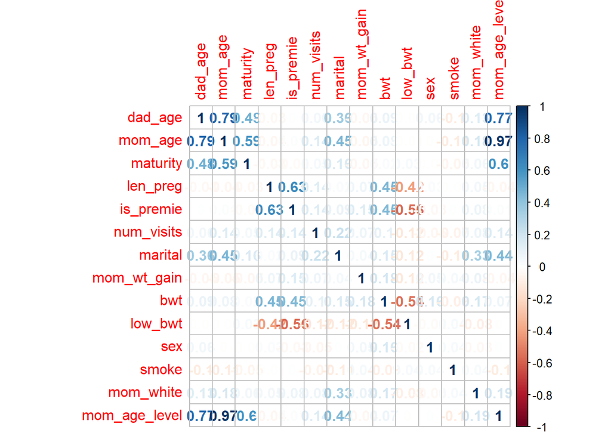

```r
corrplot(c2, method="number")
```

Interpretation: Using Spearman correlation we can see that Father’s Age and Mother’s age is highly correlated. Also, Maturity Status and Mother’s age. which is expected since maturity is defined in this data set at mother’s maturity status. Length of Pregnancy and Premature status is also highly correlated at .63 Low birth weight status and Premature status of the baby is also highly correlated. Lastly, Mother’s age and Mother’s age level is highly correlated at .97 and it is expected.

Subsetting Births into Births3 and Imputing the Data

```r
births3<-births
summary(births2)
```

```
##     dad_age         mom_age      maturity        len_preg       is_premie
##  Min.   :14.00   Min.   :13   Min.   :1.000   Min.   :20.00   Min.   :1.000
##  1st Qu.:25.00   1st Qu.:22   1st Qu.:1.000   1st Qu.:37.00   1st Qu.:2.000
##  Median :30.00   Median :27   Median :1.000   Median :39.00   Median :2.000
##  Mean   :30.26   Mean   :27   Mean   :1.133   Mean   :38.33   Mean   :1.848
##  3rd Qu.:35.00   3rd Qu.:32   3rd Qu.:1.000   3rd Qu.:40.00   3rd Qu.:2.000
##  Max.   :55.00   Max.   :50   Max.   :2.000   Max.   :45.00   Max.   :2.000
##  NA's   :171                                  NA's   :2       NA's   :2
##    num_visits      marital       mom_wt_gain         bwt
##  Min.   : 0.0   Min.   :1.000   Min.   : 0.00   Min.   : 1.000
##  1st Qu.:10.0   1st Qu.:1.000   1st Qu.:20.00   1st Qu.: 6.380
##  Median :12.0   Median :2.000   Median :30.00   Median : 7.310
##  Mean   :12.1   Mean   :1.614   Mean   :30.33   Mean   : 7.101
##  3rd Qu.:15.0   3rd Qu.:2.000   3rd Qu.:38.00   3rd Qu.: 8.060
##  Max.   :30.0   Max.   :2.000   Max.   :85.00   Max.   :11.750
##  NA's   :9      NA's   :1       NA's   :27
##     low_bwt           sex            smoke         mom_white
##  Min.   :1.000   Min.   :1.000   Min.   :1.000   Min.   :1.000
##  1st Qu.:1.000   1st Qu.:1.000   1st Qu.:1.000   1st Qu.:1.000
##  Median :1.000   Median :1.000   Median :1.000   Median :2.000
##  Mean   :1.111   Mean   :1.497   Mean   :1.126   Mean   :1.715
##  3rd Qu.:1.000   3rd Qu.:2.000   3rd Qu.:1.000   3rd Qu.:2.000
##  Max.   :2.000   Max.   :2.000   Max.   :2.000   Max.   :2.000
##                                  NA's   :1       NA's   :2
##  mom_age_level
##  Min.   :1.000
##  1st Qu.:2.000
##  Median :3.000
##  Mean   :2.984
##  3rd Qu.:4.000
##  Max.   :5.000
##
```

```r
cor(births2, use= "pairwise.complete.obs")
```

```
##                    dad_age      mom_age     maturity    len_preg    is_premie
## dad_age        1.000000000  0.780506784  0.498072737 -0.01607193 -0.003744287
## mom_age        0.780506784  1.000000000  0.642034663 -0.03208743  0.007245640
## maturity       0.498072737  0.642034663  1.000000000 -0.04156444 -0.023836636
## len_preg      -0.016071926 -0.032087430 -0.041564439  1.00000000  0.735561997
## is_premie     -0.003744287  0.007245640 -0.023836636  0.73556200  1.000000000
## num_visits     0.081386874  0.160622020  0.049933949  0.17613607  0.146222396
## marital        0.346213418  0.438367519  0.157858725  0.06894203  0.087095443
## mom_wt_gain   -0.043100500 -0.060635332 -0.042163216  0.09140028  0.133239649
## bwt            0.070234033  0.055065889  0.006379432  0.67010134  0.556294999
## low_bwt        0.002575852 -0.002050325  0.030345546 -0.58946900 -0.563192923
## sex            0.059039112 -0.008695144 -0.006484698  0.01915347 -0.030435326
## smoke         -0.088674254 -0.106655019 -0.050294575  0.01424134  0.001598465
## mom_white      0.115915133  0.168694281  0.056131765  0.09792439  0.078280577
## mom_age_level  0.747306810  0.966384765  0.650864617 -0.02782607  0.009445788
##                num_visits      marital mom_wt_gain          bwt       low_bwt
## dad_age        0.08138687  0.346213418 -0.04310050  0.070234033  0.0025758518
## mom_age        0.16062202  0.438367519 -0.06063533  0.055065889 -0.0020503254
## maturity       0.04993395  0.157858725 -0.04216322  0.006379432  0.0303455463
## len_preg       0.17613607  0.068942032  0.09140028  0.670101337 -0.5894690037
## is_premie      0.14622240  0.087095443  0.13323965  0.556294999 -0.5631929235
## num_visits     1.00000000  0.229365818  0.05986466  0.134883015 -0.1157802436
## marital        0.22936582  1.000000000  0.02491982  0.160184652 -0.1214807188
## mom_wt_gain    0.05986466  0.024919823  1.00000000  0.154171555 -0.1032652810
## bwt            0.13488301  0.160184652  0.15417155  1.000000000 -0.7184274191
## low_bwt       -0.11578024 -0.121480719 -0.10326528 -0.718427419  1.0000000000
## sex           -0.04025309  0.004251541  0.03610051  0.132158904 -0.0201638523
## smoke         -0.07390453 -0.107220940  0.04257223 -0.069612974  0.0397437068
## mom_white      0.07672623  0.330148687  0.07304234  0.159004088 -0.0806105991
## mom_age_level  0.16036324  0.439358564 -0.05179949  0.057935076 -0.0005877864
##                        sex        smoke   mom_white mom_age_level
## dad_age        0.059039112 -0.088674254  0.11591513  0.7473068098
## mom_age       -0.008695144 -0.106655019  0.16869428  0.9663847649
## maturity      -0.006484698 -0.050294575  0.05613177  0.6508646169
## len_preg       0.019153469  0.014241340  0.09792439 -0.0278260709
## is_premie     -0.030435326  0.001598465  0.07828058  0.0094457881
## num_visits    -0.040253087 -0.073904533  0.07672623  0.1603632440
## marital        0.004251541 -0.107220940  0.33014869  0.4393585637
## mom_wt_gain    0.036100511  0.042572229  0.07304234 -0.0517994866
## bwt            0.132158904 -0.069612974  0.15900409  0.0579350755
## low_bwt       -0.020163852  0.039743707 -0.08061060 -0.0005877864
## sex            1.000000000  0.038083607 -0.03170509 -0.0017277582
## smoke          0.038083607  1.000000000  0.03940358 -0.0988304817
## mom_white     -0.031705094  0.039403578  1.00000000  0.1871438555
## mom_age_level -0.001727758 -0.098830482  0.18714386  1.0000000000
```

```r
births3$dad_age <- NULL
births3$len_preg[is.na(births3$len_preg)] <- mean(births2$len_preg,na.rm=T)
births3$is_premie[is.na(births3$is_premie)] <- "Full-term"
births3$num_visits[is.na(births3$num_visits)] <- mean(births2$num_visits,na.rm=T)
births3$marital[is.na(births3$marital)] <- "Married"
births3$mom_wt_gain[is.na(births3$mom_wt_gain)] <- mean(births2$mom_wt_gain,na.rm=T)
births3$smoke[is.na(births3$smoke)] <- "Non-Smoker"
births3$mom_white[is.na(births3$mom_white)] <- "White"
summary(births3)
```

```
##     mom_age       maturity      len_preg         is_premie     num_visits
##  Min.   :13   Younger :867   Min.   :20.00   Premie   :152   Min.   : 0.0
##  1st Qu.:22   Advanced:133   1st Qu.:37.00   Full-term:848   1st Qu.:10.0
##  Median :27                  Median :39.00                   Median :12.0
##  Mean   :27                  Mean   :38.33                   Mean   :12.1
##  3rd Qu.:32                  3rd Qu.:40.00                   3rd Qu.:15.0
##  Max.   :50                  Max.   :45.00                   Max.   :30.0
##       marital     mom_wt_gain         bwt            low_bwt        sex
##  Unmarried:386   Min.   : 0.00   Min.   : 1.000   Not Low:889   Female:503
##  Married  :614   1st Qu.:21.00   1st Qu.: 6.380   Low    :111   Male  :497
##                  Median :30.00   Median : 7.310
##                  Mean   :30.33   Mean   : 7.101
##                  3rd Qu.:38.00   3rd Qu.: 8.060
##                  Max.   :85.00   Max.   :11.750
##         smoke         mom_white      mom_age_level
##  Non-Smoker:874   Non-White:284   Teens     :110
##  Smoker    :126   White    :716   Early 20's:281
##                                   Late 20's :257
##                                   Early 30's:219
##                                   35+       :133
##
```

Interpretation: Father’s age has a large number of NA’s at 171. This had to be removed by turning the column null. Mother’s age has a good correlation between that variable at .78 and will be used in liue of that. For numeric variables the mean is used to impute the NA’s and for the factored variables the median is used to impute the NA’s

Fitting a Linear Regression Model First Model

```r
fitlin1<- lm(bwt~dad_age+mom_age+maturity+len_preg+is_premie+num_visits+marital+mom_wt_gain+low_bwt+sex+smoke+mom_white+mom_age_level, data=births)
summary(fitlin1)
```

```
##
## Call:
## lm(formula = bwt ~ dad_age + mom_age + maturity + len_preg +
##     is_premie + num_visits + marital + mom_wt_gain + low_bwt +
##     sex + smoke + mom_white + mom_age_level, data = births)
##
## Residuals:
##     Min      1Q  Median      3Q     Max
## -2.4770 -0.6012 -0.0021  0.5494  3.5563
##
## Coefficients: (1 not defined because of singularities)
##                           Estimate Std. Error t value Pr(>|t|)
## (Intercept)             -0.3795044  0.7466477  -0.508  0.61140
## dad_age                  0.0080555  0.0077365   1.041  0.29809
## mom_age                  0.0090994  0.0218822   0.416  0.67764
## maturityAdvanced        -0.0731887  0.4196130  -0.174  0.86158
## len_preg                 0.1718275  0.0181833   9.450  < 2e-16 ***
## is_premieFull-term       0.0442754  0.1440740   0.307  0.75869
## num_visits               0.0003972  0.0089395   0.044  0.96457
## maritalMarried           0.1172818  0.0853089   1.375  0.16959
## mom_wt_gain              0.0071629  0.0023449   3.055  0.00233 **
## low_bwtLow              -2.3881336  0.1431235 -16.686  < 2e-16 ***
## sexMale                  0.3821920  0.0653943   5.844 7.45e-09 ***
## smokeSmoker             -0.2143158  0.1068650  -2.005  0.04525 *
## mom_whiteWhite           0.2458025  0.0807928   3.042  0.00243 **
## mom_age_levelEarly 20's  0.0825564  0.1538582   0.537  0.59171
## mom_age_levelLate 20's   0.0187617  0.2309455   0.081  0.93527
## mom_age_levelEarly 30's -0.0630545  0.3222707  -0.196  0.84493
## mom_age_level35+                NA         NA      NA       NA
## ---
## Signif. codes:  0 '***' 0.001 '**' 0.01 '*' 0.05 '.' 0.1 ' ' 1
##
## Residual standard error: 0.9136 on 784 degrees of freedom
##   (200 observations deleted due to missingness)
## Multiple R-squared:  0.6055, Adjusted R-squared:  0.598
## F-statistic: 80.24 on 15 and 784 DF,  p-value: < 2.2e-16
```

Interpretation: This model has an adjusted r-squared of .59. This predits 59 percent of the variablity of this model. This can be a better model by removing the insignificant variables. Before removing the insignificant variables there is a variable that is highly correlated and is an alias to bwt and that is low_bwt intially we need to remove this first.

Second Model

```r
fitlin2<- lm(bwt~dad_age + mom_age + maturity + len_preg + is_premie + num_visits +
    marital + mom_wt_gain + sex + smoke + mom_white +
    mom_age_level, data=births)
summary(fitlin2)
```

```
##
## Call:
## lm(formula = bwt ~ dad_age + mom_age + maturity + len_preg +
##     is_premie + num_visits + marital + mom_wt_gain + sex + smoke +
##     mom_white + mom_age_level, data = births)
##
## Residuals:
##     Min      1Q  Median      3Q     Max
## -3.6885 -0.6426 -0.0200  0.6655  3.7236
##
## Coefficients: (1 not defined because of singularities)
##                          Estimate Std. Error t value Pr(>|t|)
## (Intercept)             -4.976019   0.807336  -6.164 1.14e-09 ***
## dad_age                  0.003913   0.008996   0.435 0.663700
## mom_age                  0.021276   0.025443   0.836 0.403277
## maturityAdvanced        -0.276792   0.487953  -0.567 0.570705
## len_preg                 0.264027   0.020153  13.101  < 2e-16 ***
## is_premieFull-term       0.618374   0.162760   3.799 0.000156 ***
## num_visits               0.003507   0.010398   0.337 0.736000
## maritalMarried           0.200323   0.099076   2.022 0.043523 *
## mom_wt_gain              0.009317   0.002724   3.420 0.000658 ***
## sexMale                  0.400607   0.076066   5.267 1.80e-07 ***
## smokeSmoker             -0.304372   0.124163  -2.451 0.014448 *
## mom_whiteWhite           0.294536   0.093929   3.136 0.001778 **
## mom_age_levelEarly 20's  0.049680   0.178977   0.278 0.781409
## mom_age_levelLate 20's  -0.032199   0.268648  -0.120 0.904628
## mom_age_levelEarly 30's -0.187359   0.374815  -0.500 0.617307
## mom_age_level35+               NA         NA      NA       NA
## ---
## Signif. codes:  0 '***' 0.001 '**' 0.01 '*' 0.05 '.' 0.1 ' ' 1
##
## Residual standard error: 1.063 on 785 degrees of freedom
##   (200 observations deleted due to missingness)
## Multiple R-squared:  0.4655, Adjusted R-squared:  0.4559
## F-statistic: 48.83 on 14 and 785 DF,  p-value: < 2.2e-16
```

Third Model

```r
fitlin3<- lm(bwt~len_preg+is_premie+marital+mom_wt_gain+sex+smoke+mom_white, data=births)
summary(fitlin3)
```

```
##
## Call:
## lm(formula = bwt ~ len_preg + is_premie + marital + mom_wt_gain +
##     sex + smoke + mom_white, data = births)
##
## Residuals:
##     Min      1Q  Median      3Q     Max
## -3.7412 -0.6448 -0.0237  0.6784  4.1543
##
## Coefficients:
##                     Estimate Std. Error t value Pr(>|t|)
## (Intercept)        -4.867923   0.588759  -8.268 4.49e-16 ***
## len_preg            0.282229   0.017408  16.212  < 2e-16 ***
## is_premieFull-term  0.523456   0.142239   3.680 0.000246 ***
## maritalMarried      0.247769   0.075388   3.287 0.001051 **
## mom_wt_gain         0.008355   0.002427   3.442 0.000602 ***
## sexMale             0.396837   0.068709   5.776 1.03e-08 ***
## smokeSmoker        -0.383683   0.104092  -3.686 0.000241 ***
## mom_whiteWhite      0.218897   0.080821   2.708 0.006880 **
## ---
## Signif. codes:  0 '***' 0.001 '**' 0.01 '*' 0.05 '.' 0.1 ' ' 1
##
## Residual standard error: 1.064 on 962 degrees of freedom
##   (30 observations deleted due to missingness)
## Multiple R-squared:  0.494,  Adjusted R-squared:  0.4903
## F-statistic: 134.2 on 7 and 962 DF,  p-value: < 2.2e-16
```

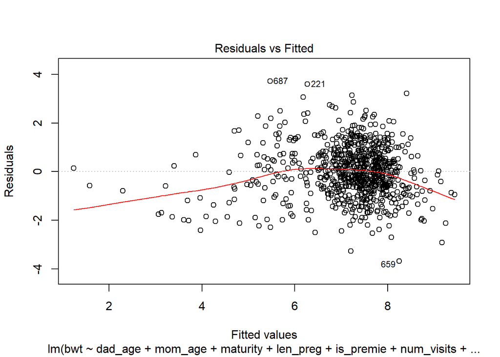

```r
plot(fitlin2,1)
```

Interpretation: The adjusted R-squared for this model is .49 better compared to the previous model. It This predits 49 percent of the variablity of this model. Also, it includes all the significant variables.It’s not the best fit but with the data set this is the most it can reach. Final Linear Model

```r
finalfitlin<-lm(bwt ~ len_preg + sex + marital + is_premie + mom_wt_gain + smoke + mom_white, data=births)
summary(finalfitlin)
```

```
##
## Call:
## lm(formula = bwt ~ len_preg + sex + marital + is_premie + mom_wt_gain +
##     smoke + mom_white, data = births)
##
## Residuals:
##     Min      1Q  Median      3Q     Max
## -3.7412 -0.6448 -0.0237  0.6784  4.1543
##
## Coefficients:
##                     Estimate Std. Error t value Pr(>|t|)
## (Intercept)        -4.867923   0.588759  -8.268 4.49e-16 ***
## len_preg            0.282229   0.017408  16.212  < 2e-16 ***
## sexMale             0.396837   0.068709   5.776 1.03e-08 ***
## maritalMarried      0.247769   0.075388   3.287 0.001051 **
## is_premieFull-term  0.523456   0.142239   3.680 0.000246 ***
## mom_wt_gain         0.008355   0.002427   3.442 0.000602 ***
## smokeSmoker        -0.383683   0.104092  -3.686 0.000241 ***
## mom_whiteWhite      0.218897   0.080821   2.708 0.006880 **
## ---
## Signif. codes:  0 '***' 0.001 '**' 0.01 '*' 0.05 '.' 0.1 ' ' 1
##
## Residual standard error: 1.064 on 962 degrees of freedom
##   (30 observations deleted due to missingness)
## Multiple R-squared:  0.494,  Adjusted R-squared:  0.4903
## F-statistic: 134.2 on 7 and 962 DF,  p-value: < 2.2e-16
```

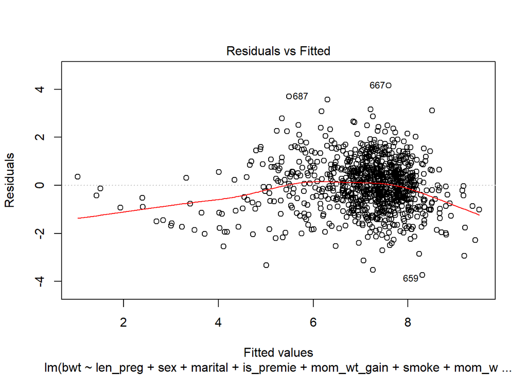

```r
plot(finalfitlin,1)
```

Interpretation: This is the final model for the final model for linear regression in this data set. The formulas is: birth weight = .28* length of pregnancy + .39* Sex of Baby(Male) + .25* Marital Status(Married) + .52* Premature Status of Baby (Full-Term)+ .008* Mother’s weight gain - .38* Smoking Status(Smoker) + .22* Mother’s Race(White)

It is interesting to point out specific variables within this model, such as; For male babies as compared with female babies birth weight increases by .39 pounds on average when all other variables in the model are held constant For married marital status as compared with unmarried birth weight increases by .25 pounds on average when all other variables in the model are held constant For smoking mothers as compared with non-smoking mothers, birth weight decreases by .38 pounds on average when all other variables in the model are held constant For white mothers as compared with non-white mothers birth weight increases by .22 pounds on average when all other variables in the model are held constant

Residuals VS. Fitted Plot There is a slight pattern, but with this current data set it is a decent fit for this model.

Logistic Regression Model

```r
fit_null <- glm(low_bwt ~ 1, family = binomial(), data = births3)
summary(fit_null)
```

```
##
## Call:
## glm(formula = low_bwt ~ 1, family = binomial(), data = births3)
##
## Deviance Residuals:
##     Min       1Q   Median       3Q      Max
## -0.4851  -0.4851  -0.4851  -0.4851   2.0968
##
## Coefficients:
##             Estimate Std. Error z value Pr(>|z|)
## (Intercept)  -2.0806     0.1007  -20.67   <2e-16 ***
## ---
## Signif. codes:  0 '***' 0.001 '**' 0.01 '*' 0.05 '.' 0.1 ' ' 1
##
## (Dispersion parameter for binomial family taken to be 1)
##
##     Null deviance: 697.2  on 999  degrees of freedom
## Residual deviance: 697.2  on 999  degrees of freedom
## AIC: 699.2
##
## Number of Fisher Scoring iterations: 4
```

```r
fit_all <-glm(low_bwt~., family=binomial(), data=births3)
summary(fit_all)
```

```
##
## Call:
## glm(formula = low_bwt ~ ., family = binomial(), data = births3)
##
## Deviance Residuals:
##        Min          1Q      Median          3Q         Max
## -3.865e-04  -2.000e-08  -2.000e-08  -2.000e-08   3.500e-04
##
## Coefficients: (1 not defined because of singularities)
##                           Estimate Std. Error z value Pr(>|z|)
## (Intercept)              1.173e+03  1.538e+05   0.008    0.994
## mom_age                  2.227e+00  3.287e+03   0.001    0.999
## maturityAdvanced        -4.391e+01  6.890e+04  -0.001    0.999
## len_preg                 6.193e+00  3.012e+03   0.002    0.998
## is_premieFull-term      -3.226e+01  7.565e+03  -0.004    0.997
## num_visits               5.761e-01  5.375e+02   0.001    0.999
## maritalMarried          -5.899e+00  7.381e+03  -0.001    0.999
## mom_wt_gain              3.675e-01  1.698e+02   0.002    0.998
## bwt                     -2.607e+02  1.323e+04  -0.020    0.984
## sexMale                  1.637e+00  3.699e+03   0.000    1.000
## smokeSmoker              2.235e+01  3.088e+04   0.001    0.999
## mom_whiteWhite           1.050e+01  1.201e+04   0.001    0.999
## mom_age_levelEarly 20's -3.523e+00  1.266e+04   0.000    1.000
## mom_age_levelLate 20's  -3.754e+01  3.429e+04  -0.001    0.999
## mom_age_levelEarly 30's -3.673e+01  3.824e+04  -0.001    0.999
## mom_age_level35+                NA         NA      NA       NA
##
## (Dispersion parameter for binomial family taken to be 1)
##
##     Null deviance: 6.9720e+02  on 999  degrees of freedom
## Residual deviance: 1.0886e-06  on 985  degrees of freedom
## AIC: 30
##
## Number of Fisher Scoring iterations: 25
```

```r
pR2(fit_all)
```

```
##           llh       llhNull            G2      McFadden          r2ML
## -5.442901e-07 -3.486010e+02  6.972020e+02  1.000000e+00  5.020233e-01
##          r2CU
##  1.000000e+00
```

```r
fit2<-glm(low_bwt ~ mom_age+len_preg+is_premie+num_visits+marital+mom_wt_gain+sex+smoke+mom_white, family= binomial(), data =births3)
summary(fit2)
```

```
##
## Call:
## glm(formula = low_bwt ~ mom_age + len_preg + is_premie + num_visits +
##     marital + mom_wt_gain + sex + smoke + mom_white, family = binomial(),
##     data = births3)
##
## Deviance Residuals:
##     Min       1Q   Median       3Q      Max
## -1.8340  -0.3194  -0.2199  -0.1342   3.4311
##
## Coefficients:
##                    Estimate Std. Error z value Pr(>|z|)
## (Intercept)        21.27482    3.55853   5.979 2.25e-09 ***
## mom_age             0.01202    0.02375   0.506   0.6129
## len_preg           -0.61891    0.10067  -6.148 7.86e-10 ***
## is_premieFull-term -0.51099    0.46317  -1.103   0.2699
## num_visits          0.03132    0.03206   0.977   0.3286
## maritalMarried     -0.69291    0.31561  -2.195   0.0281 *
## mom_wt_gain        -0.01089    0.01032  -1.055   0.2913
## sexMale            -0.37241    0.27699  -1.344   0.1788
## smokeSmoker         0.61783    0.36267   1.704   0.0885 .
## mom_whiteWhite     -0.03100    0.30871  -0.100   0.9200
## ---
## Signif. codes:  0 '***' 0.001 '**' 0.01 '*' 0.05 '.' 0.1 ' ' 1
##
## (Dispersion parameter for binomial family taken to be 1)
##
##     Null deviance: 697.20  on 999  degrees of freedom
## Residual deviance: 395.14  on 990  degrees of freedom
## AIC: 415.14
##
## Number of Fisher Scoring iterations: 6
```

Interpretation: Before running the step function we create logistic models for null and main effects. After looking at the summary of all main effects model it is clear that there are a number of variables that are strongly correlated to each other.An indicator would be the perfect McFadden score of 1 which is unrealistic. Also, the NA’s for mom_age_level 35+. After removing those variables we ended up with a fit2 model that will be used as an upper limit on the step function.

Running Step Function to find the best fit model.

```r
fit_step1 = step(fit_null, scope=list(lower=fit_null, upper=fit2),direction="both")
```

```
## Start:  AIC=699.2
## low_bwt ~ 1
##
##               Df Deviance    AIC
## + len_preg     1   408.38 412.38
## + is_premie    1   476.30 480.30
## + marital      1   683.50 687.50
## + num_visits   1   683.96 687.96
## + mom_wt_gain  1   686.72 690.72
## + mom_white    1   690.98 694.98
## <none>             697.20 699.20
## + smoke        1   695.81 699.81
## + sex          1   696.80 700.80
## + mom_age      1   697.20 701.20
##
## Step:  AIC=412.38
## low_bwt ~ len_preg
##
##               Df Deviance    AIC
## + marital      1   402.79 408.79
## + smoke        1   405.98 411.98
## <none>             408.38 412.38
## + mom_wt_gain  1   406.58 412.58
## + sex          1   406.89 412.89
## + is_premie    1   407.06 413.06
## + mom_white    1   407.75 413.75
## + mom_age      1   408.26 414.26
## + num_visits   1   408.30 414.30
## - len_preg     1   697.20 699.20
##
## Step:  AIC=408.79
## low_bwt ~ len_preg + marital
##
##               Df Deviance    AIC
## <none>             402.79 408.79
## + smoke        1   400.89 408.89
## + sex          1   401.35 409.35
## + mom_wt_gain  1   401.49 409.49
## + is_premie    1   401.60 409.60
## + num_visits   1   401.91 409.91
## + mom_age      1   402.36 410.36
## + mom_white    1   402.79 410.79
## - marital      1   408.38 412.38
## - len_preg     1   683.50 687.50
```

```r
summary(fit_step1)
```

```
##
## Call:
## glm(formula = low_bwt ~ len_preg + marital, family = binomial(),
##     data = births3)
##
## Deviance Residuals:
##     Min       1Q   Median       3Q      Max
## -1.9703  -0.3076  -0.2185  -0.1501   3.4282
##
## Coefficients:
##                Estimate Std. Error z value Pr(>|z|)
## (Intercept)    24.06882    2.22903  10.798   <2e-16 ***
## len_preg       -0.69634    0.06065 -11.482   <2e-16 ***
## maritalMarried -0.63527    0.26836  -2.367   0.0179 *
## ---
## Signif. codes:  0 '***' 0.001 '**' 0.01 '*' 0.05 '.' 0.1 ' ' 1
##
## (Dispersion parameter for binomial family taken to be 1)
##
##     Null deviance: 697.20  on 999  degrees of freedom
## Residual deviance: 402.79  on 997  degrees of freedom
## AIC: 408.79
##
## Number of Fisher Scoring iterations: 6
```

Interpretation: After running the step function we are able to find the best model for this data set. with a low AIC of 408.79. glm(formula = low_bwt ~ len_preg + marital, family = binomial(), data = births3)

Final Logistic Model:

```r
finlogfit<- glm(low_bwt ~ len_preg + marital, family = binomial(), data=births3)
summary(finlogfit)
```

```
##
## Call:
## glm(formula = low_bwt ~ len_preg + marital, family = binomial(),
##     data = births3)
##
## Deviance Residuals:
##     Min       1Q   Median       3Q      Max
## -1.9703  -0.3076  -0.2185  -0.1501   3.4282
##
## Coefficients:
##                Estimate Std. Error z value Pr(>|z|)
## (Intercept)    24.06882    2.22903  10.798   <2e-16 ***
## len_preg       -0.69634    0.06065 -11.482   <2e-16 ***
## maritalMarried -0.63527    0.26836  -2.367   0.0179 *
## ---
## Signif. codes:  0 '***' 0.001 '**' 0.01 '*' 0.05 '.' 0.1 ' ' 1
##
## (Dispersion parameter for binomial family taken to be 1)
##
##     Null deviance: 697.20  on 999  degrees of freedom
## Residual deviance: 402.79  on 997  degrees of freedom
## AIC: 408.79
##
## Number of Fisher Scoring iterations: 6
```

```r
pR2(finlogfit)
```

```
##          llh      llhNull           G2     McFadden         r2ML         r2CU
## -201.3960703 -348.6009843  294.4098280    0.4222734    0.2550289    0.5080021
```

```r
expfit<-exp(cbind(OR = coef(finlogfit), confint(finlogfit)))
expfit
```

```
##                          OR        2.5 %       97.5 %
## (Intercept)    2.837618e+10 4.412734e+08 2.789563e+12
## len_preg       4.984081e-01 4.398559e-01 5.581195e-01
## maritalMarried 5.297938e-01 3.119910e-01 8.965434e-01
```

Interpretation: This is the final model for logistic regression. low_bwt ~ len_preg + marital The McFadden score for pseudo r-squared is a good fit at .42.

Log Odds: For every week increase in length of pregnancy of the mother, the log odds of having low birth weight for the baby decreases by -0.69634 on average, when all other variables in the model are held constant. For married marital status as compared with unmarried the log odds of having low birth weight for the baby decreases by -0.63527 on average.